# Monte-Carlo Simulation and Kernel Density Estimation of First passage time

A.C. Guidoum[^1] and K. Boukhetala[^2]

2020-03-27

# The `fptsdekd()` functions

A new algorithm based on the Monte Carlo technique to generate the random variable FPT of a time homogeneous diffusion process (1, 2 and 3D) through a time-dependent boundary, order to estimate her probability density function.

Let $X_t$ be a diffusion process which is the unique solution of the following stochastic differential equation:

$$\begin{equation}\label{eds01}
dX_t = \mu(t,X_t) dt + \sigma(t,X_t) dW_t,\quad X_{t_{0}}=x_{0}
\end{equation}$$

if $S(t)$ is a time-dependent boundary, we are interested in generating the first passage time (FPT) of the diffusion process through this boundary that is we will study the following random variable:

$$\tau_{S(t)}=
\left\{
\begin{array}{ll}
inf \left\{t: X_{t} \geq S(t)|X_{t_{0}}=x_{0} \right\} & \hbox{if} \quad x_{0} \leq S(t_{0}) \\
inf \left\{t: X_{t} \leq S(t)|X_{t_{0}}=x_{0} \right\} & \hbox{if} \quad x_{0} \geq S(t_{0})
\end{array}
\right.$$

The main arguments to ‘random’ `fptsdekd()` (where `k=1,2,3`) consist:

- `object` an object inheriting from class `snssde1d`, `snssde2d` and `snssde3d`.
- `boundary` an expression of a constant or time-dependent boundary $S(t)$.

The following statistical measures (`S3 method`) for class `fptsdekd()` can be approximated for F.P.T $\tau_{S(t)}$:

- The expected value $\text{E}(\tau_{S(t)})$, using the command `mean`.
- The variance $\text{Var}(\tau_{S(t)})$, using the command `moment` with `order=2` and `center=TRUE`.
- The median $\text{Med}(\tau_{S(t)})$, using the command `Median`.
- The mode $\text{Mod}(\tau_{S(t)})$, using the command `Mode`.
- The quartile of $\tau_{S(t)}$, using the command `quantile`.
- The maximum and minimum of $\tau_{S(t)}$, using the command `min` and `max`.
- The skewness and the kurtosis of $\tau_{S(t)}$, using the command `skewness` and `kurtosis`.
- The coefficient of variation (relative variability) of $\tau_{S(t)}$, using the command `cv`.
- The central moments up to order $p$ of $\tau_{S(t)}$, using the command `moment`.
- The result summaries of the results of Monte-Carlo simulation, using the command `summary`.

The main arguments to ‘density’ `dfptsdekd()` (where `k=1,2,3`) consist:

- `object` an object inheriting from class `fptsdekd()` (where `k=1,2,3`).
- `pdf` probability density function `Joint` or `Marginal`.

# Examples

## FPT for 1-Dim SDE

$$\begin{align*}
dX_{t}= & (1-0.5 X_{t}) dt + dW_{t},~x_{0} =1.7.\\
S(t)= & 2(1-sinh(0.5t))
\end{align*}$$

Generating the first passage time (FPT) of this model through this boundary:
$$\tau_{S(t)}=
\inf \left\{t: X_{t} \geq S(t) |X_{t_{0}}=x_{0} \right\} ~~ \text{if} \quad x_{0} \leq S(t_{0})$$

Set the model $X_t$:

```r
R> f <- expression( (1-0.5*x) )
R> g <- expression( 1 )
R> mod1d <- snssde1d(drift=f,diffusion=g,x0=1.7,M=1000,method="taylor")
```

Generate the first-passage-time $\tau_{S(t)}$, with `fptsde1d()` function ( based on `density()` function in [base] package):

```r
R> St  <- expression(2*(1-sinh(0.5*t)) )
R> fpt1d <- fptsde1d(mod1d, boundary = St)
R> fpt1d
```

```
Itô Sde 1D:
    | dX(t) = (1 - 0.5 * X(t)) * dt + 1 * dW(t)
    | t in [0,1].
Boundary:
    | S(t) = 2 * (1 - sinh(0.5 * t))
F.P.T:
    | T(S(t),X(t)) = inf{t >=  0 : X(t) >=  2 * (1 - sinh(0.5 * t)) }
    | Crossing realized 965 among 1000.
```

```r
R> head(fpt1d$fpt, n = 10)
```

```
 [1] 0.107542 0.203707 0.089800 0.067849 0.240718 0.187920 0.416042
 [8] 0.054746 0.025669 0.061076
```

The following statistical measures (`S3 method`) for class `fptsde1d()` can be approximated for the first-passage-time $\tau_{S(t)}$:

```r
R> mean(fpt1d)
```

```
[1] 0.20638
```

```r
R> moment(fpt1d , center = TRUE , order = 2) ## variance
```

[output not shown]

```r
R> Median(fpt1d)
```

```
[1] 0.13043
```

```r
R> Mode(fpt1d)
```

```
[1] 0.061989
```

```r
R> quantile(fpt1d)
```

```
       0%       25%       50%       75%      100%
0.0097554 0.0603962 0.1304262 0.2780265 0.9962872
```

```r
R> kurtosis(fpt1d)
```

```
[1] 5.0625
```

```r
R> skewness(fpt1d)
```

```
[1] 1.5834
```

```r
R> cv(fpt1d)
```

```
[1] 0.98461
```

```r
R> min(fpt1d)
```

```
[1] 0.0097554
```

```r
R> max(fpt1d)
```

```
[1] 0.99629
```

```r
R> moment(fpt1d , center= TRUE , order = 4)
```

```
[1] 0.0086314
```

```r
R> moment(fpt1d , center= FALSE , order = 4)
```

```
[1] 0.031954
```

The result summaries of the first-passage-time $\tau_{S(t)}$:

```r
R> summary(fpt1d)
```

```
Monte-Carlo Statistics of F.P.T:
|T(S(t),X(t)) = inf{t >=  0 : X(t) >=  2 * (1 - sinh(0.5 * t)) }

Mean             0.20638
Variance         0.04129
Median           0.13043
Mode             0.06199
First quartile   0.06040
Third quartile   0.27803
Minimum          0.00976
Maximum          0.99629
Skewness         1.58338
Kurtosis         5.06251
Coef-variation   0.98461
3th-order moment 0.01329
4th-order moment 0.00863
5th-order moment 0.00499
6th-order moment 0.00320
```

Display the exact first-passage-time $\tau_{S(t)}$, see Figure 1:

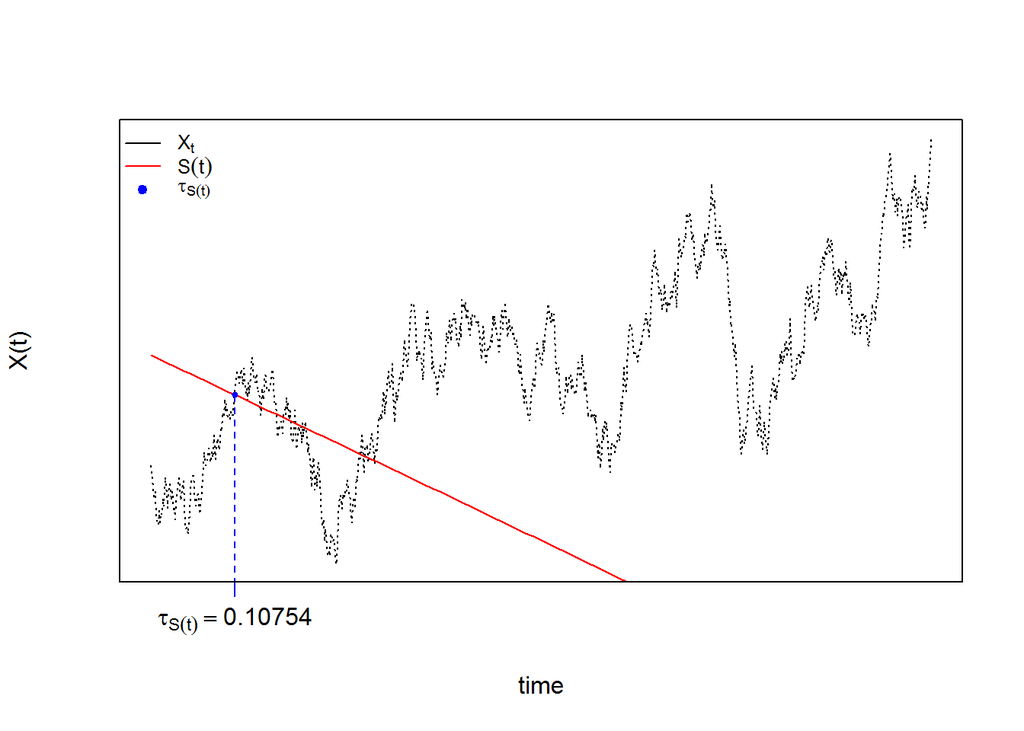

```r
R> plot(time(mod1d),mod1d$X[,1],type="l",lty=3,ylab="X(t)",xlab="time",axes=F)
R> curve(2*(1-sinh(0.5*x)),add=TRUE,col=2)
R> points(fpt1d$fpt[1],2*(1-sinh(0.5*fpt1d$fpt[1])),pch=19,col=4,cex=0.5)
R> lines(c(fpt1d$fpt[1],fpt1d$fpt[1]),c(0,2*(1-sinh(0.5*fpt1d$fpt[1]))),lty=2,col=4)
R> axis(1, fpt1d$fpt[1], bquote(tau[S(t)]==.(fpt1d$fpt[1])),col=4,col.ticks=4)
R> legend('topleft',col=c(1,2,4),lty=c(1,1,NA),pch=c(NA,NA,19),legend=c(expression(X[t]),expression(S(t)),expression(tau[S(t)])),cex=0.8,bty = 'n')
R> box()
```

The kernel density approximation of ‘fpt1d’, using `dfptsde1d()` function (`hist=TRUE` based on `truehist()` function in MASS package), see e.g. Figure 2.

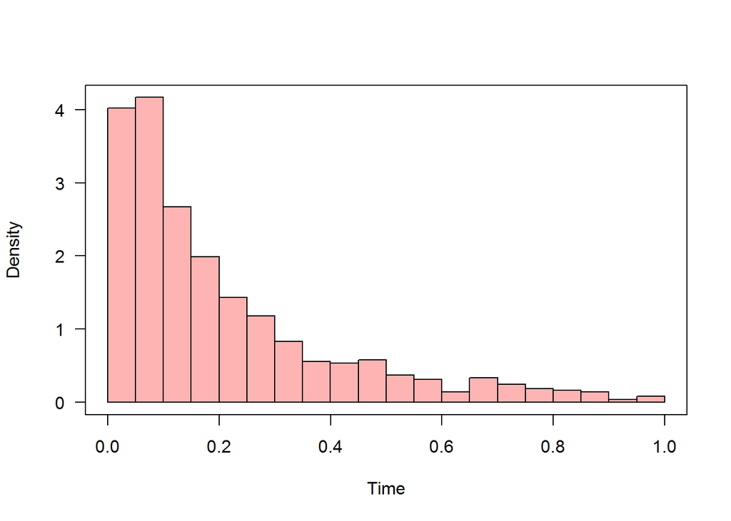

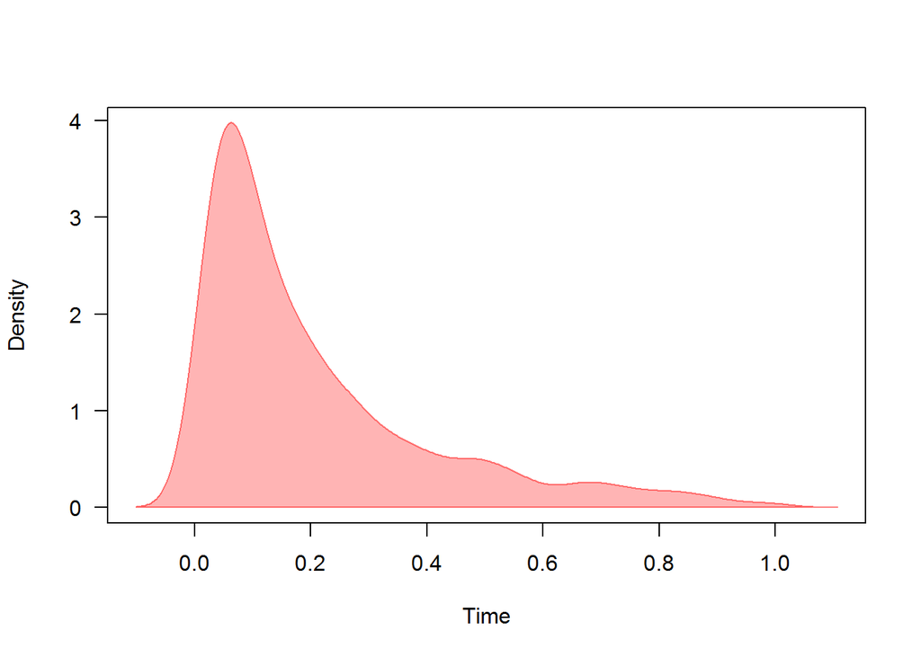

```r
R> plot(dfptsde1d(fpt1d),hist=TRUE,nbins="FD")  ## histogramm
R> plot(dfptsde1d(fpt1d))              ## kernel density
```

Since fptdApprox and DiffusionRgqd packages can very effectively handle first passage time problems for diffusions with analytically tractable transitional densities we use it to compare some of the results from the Sim.DiffProc package.

### `fptsde1d()` vs `Approx.fpt.density()`

Consider for example a diffusion process with SDE:

$$\begin{align*}
dX_{t}= & 0.48 X_{t} dt + 0.07 X_{t} dW_{t},~x_{0} =1.\\
S(t)= & 7 + 3.2 t + 1.4 t \sin(1.75 t)
\end{align*}$$
The resulting object is then used by the `Approx.fpt.density()` function in package fptdApprox to approximate the first passage time density:

```r
R> require(fptdApprox)
R> x <- character(4)
R> x[1] <- "m * x"
R> x[2] <- "(sigma^2) * x^2"
R> x[3] <- "dnorm((log(x) - (log(y) + (m - sigma^2/2) * (t- s)))/(sigma * sqrt(t - s)),0,1)/(sigma * sqrt(t - s) * x)"
R> x[4] <- "plnorm(x,log(y) + (m - sigma^2/2) * (t - s),sigma * sqrt(t - s))"
R> Lognormal <- diffproc(x)
R> res1 <- Approx.fpt.density(Lognormal, 0, 10, 1, "7 + 3.2 * t + 1.4 * t * sin(1.75 * t)",list(m = 0.48,sigma = 0.07))
```

Using `fptsde1d()` and `dfptsde1d()` functions in the Sim.DiffProc package:

```r
R> ## Set the model X(t)
R> f <- expression( 0.48*x )
R> g <- expression( 0.07*x )
R> mod1 <- snssde1d(drift=f,diffusion=g,x0=1,T=10,M=1000)
R> ## Set the boundary S(t)
R> St  <- expression( 7 + 3.2 * t + 1.4 * t * sin(1.75 * t) )
R> ## Generate the fpt
R> fpt1 <- fptsde1d(mod1, boundary = St)
R> fpt1
```

```
Itô Sde 1D:
    | dX(t) = 0.48 * X(t) * dt + 0.07 * X(t) * dW(t)
    | t in [0,10].
Boundary:
    | S(t) = 7 + 3.2 * t + 1.4 * t * sin(1.75 * t)
F.P.T:
    | T(S(t),X(t)) = inf{t >=  0 : X(t) >=  7 + 3.2 * t + 1.4 * t * sin(1.75 * t) }
    | Crossing realized 1000 among 1000.
```

```r
R> head(fpt1$fpt, n = 10)
```

```
 [1] 8.4117 5.8765 6.2605 6.0622 6.0488 8.3695 6.0661 6.4495 6.1632
[10] 8.4051
```

```r
R> summary(fpt1)
```

```
Monte-Carlo Statistics of F.P.T:
|T(S(t),X(t)) = inf{t >=  0 : X(t) >=  7 + 3.2 * t + 1.4 * t * sin(1.75 * t) }

Mean              6.51683
Variance          0.88330
Median            6.11985
Mode              6.06244
First quartile    5.96986
Third quartile    6.37719
Minimum           5.49777
Maximum           9.10482
Skewness          1.49664
Kurtosis          3.51957
Coef-variation    0.14422
3th-order moment  1.24246
4th-order moment  2.74605
5th-order moment  5.30548
6th-order moment 10.83898
```

By plotting the approximations:

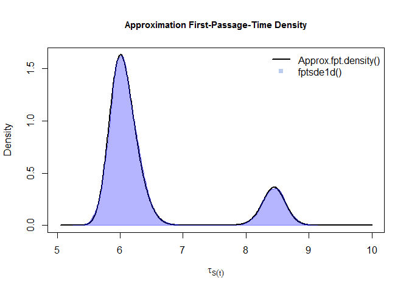

`fptsde1d()` vs `Approx.fpt.density()`

```r
R> plot(res1$y ~ res1$x, type = 'l',main = 'Approximation First-Passage-Time Density', ylab = 'Density', xlab = expression(tau[S(t)]),cex.main = 0.95,lwd=2)
R> plot(dfptsde1d(fpt1,bw="bcv"),add=TRUE)
R> legend('topright', lty = c(1, NA), col = c(1,'#BBCCEE'),pch=c(NA,15),legend = c('Approx.fpt.density()', 'fptsde1d()'), lwd = 2, bty = 'n')
```

### `fptsde1d()` vs `GQD.TIpassage()`

Consider for example a diffusion process with SDE:

$$\begin{align*}
dX_{t}= & \theta_{1}X_{t}(10+0.2\sin(2\pi t)+0.3\sqrt(t)(1+\cos(3\pi t))-X_{t}) ) dt + \sqrt(0.1) X_{t} dW_{t},~x_{0} =8.\\
S(t)= & 12
\end{align*}$$
The resulting object is then used by the `GQD.TIpassage()` function in package DiffusionRgqd to approximate the first passage time density:

```r
R> require(DiffusionRgqd)
R> G1 <- function(t)
+      {
+  theta[1] * (10+0.2 * sin(2 * pi * t) + 0.3 * prod(sqrt(t),
+  1+cos(3 * pi * t)))
+  }
R> G2 <- function(t){-theta[1]}
R> Q2 <- function(t){0.1}
R> res2 = GQD.TIpassage(8, 12, 1, 4, 1 / 100, theta = c(0.5))
```

Using `fptsde1d()` and `dfptsde1d()` functions in the Sim.DiffProc package:

```r
R> ## Set the model X(t)
R> theta1=0.5
R> f <- expression( theta1*x*(10+0.2*sin(2*pi*t)+0.3*sqrt(t)*(1+cos(3*pi*t))-x) )
R> g <- expression( sqrt(0.1)*x )
R> mod2 <- snssde1d(drift=f,diffusion=g,x0=8,t0=1,T=4,M=1000)
R> ## Set the boundary S(t)
R> St  <- expression( 12 )
R> ## Generate the fpt
R> fpt2 <- fptsde1d(mod2, boundary = St)
R> fpt2
```

```
Itô Sde 1D:
    | dX(t) = theta1 * X(t) * (10 + 0.2 * sin(2 * pi * t) + 0.3 * sqrt(t) *     (1 + cos(3 * pi * t)) - X(t)) * dt + sqrt(0.1) * X(t) * dW(t)
    | t in [1,4].
Boundary:
    | S(t) = 12
F.P.T:
    | T(S(t),X(t)) = inf{t >=  1 : X(t) >=  12 }
    | Crossing realized 924 among 1000.
```

```r
R> head(fpt2$fpt, n = 10)
```

```
 [1] 1.2159 1.4396 2.9346 3.3582 2.9095 2.0872 2.1483 2.6700 2.1994
[10] 1.5246
```

```r
R> summary(fpt2)
```

```
Monte-Carlo Statistics of F.P.T:
|T(S(t),X(t)) = inf{t >=  1 : X(t) >=  12 }

Mean             2.14945
Variance         0.48577
Median           2.06170
Mode             1.46280
First quartile   1.51230
Third quartile   2.65939
Minimum          1.11332
Maximum          3.97248
Skewness         0.56845
Kurtosis         2.27088
Coef-variation   0.32426
3th-order moment 0.19246
4th-order moment 0.53586
5th-order moment 0.48835
6th-order moment 0.88108
```

By plotting the approximations (`hist=TRUE` based on `truehist()` function in MASS package):

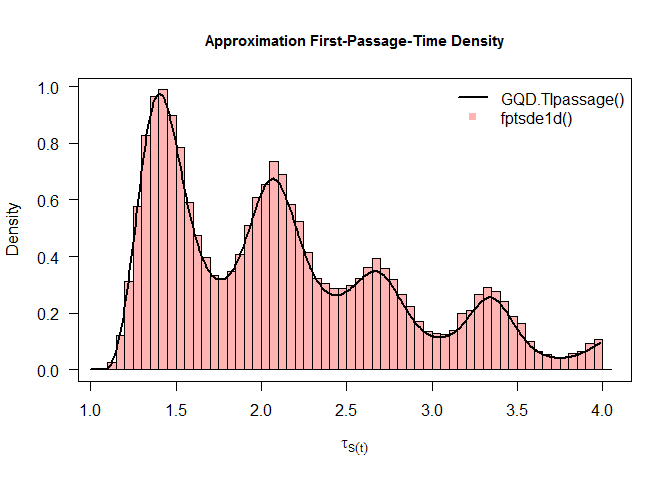

`fptsde1d()` vs `GQD.TIpassage()`

```r
R> plot(dfptsde1d(fpt2),hist=TRUE,nbins = "Scott",main = 'Approximation First-Passage-Time Density', ylab = 'Density', xlab = expression(tau[S(t)]), cex.main = 0.95)
R> lines(res2$density ~ res2$time, type = 'l',lwd=2)
R> legend('topright', lty = c(1, NA), col = c(1,'#FF00004B'),pch=c(NA,15),legend = c('GQD.TIpassage()', 'fptsde1d()'), lwd = 2, bty = 'n')
```

## FPT for 2-Dim SDE’s

The following $2$-dimensional SDE’s with a vector of drift and a diagonal matrix of diffusion coefficients:

$$\begin{equation}\label{eq:09}
\begin{cases}
dX_t = f_{x}(t,X_{t},Y_{t}) dt + g_{x}(t,X_{t},Y_{t}) dW_{1,t}\\
dY_t = f_{y}(t,X_{t},Y_{t}) dt + g_{y}(t,X_{t},Y_{t}) dW_{2,t}
\end{cases}
\end{equation}$$

$W_{1,t}$ and $W_{2,t}$ is a two independent standard Wiener process. First passage time (2D) $(\tau_{(S(t),X_{t})},\tau_{(S(t),Y_{t})})$ is defined as:

$$\left\{
\begin{array}{ll}
\tau_{S(t),X_{t}}=\inf \left\{t: X_{t} \geq S(t)|X_{t_{0}}=x_{0} \right\} & \hbox{if} \quad x_{0} \leq S(t_{0}) \\
\tau_{S(t),Y_{t}}=\inf \left\{t: Y_{t} \geq S(t)|Y_{t_{0}}=y_{0} \right\} & \hbox{if} \quad y_{0} \leq S(t_{0})
\end{array}
\right.$$
and
$$\left\{
\begin{array}{ll}
\tau_{S(t),X_{t}}= \inf \left\{t: X_{t} \leq S(t)|X_{t_{0}}=x_{0} \right\} & \hbox{if} \quad x_{0} \geq S(t_{0}) \\
\tau_{S(t),Y_{t}}= \inf \left\{t: Y_{t} \leq S(t)|Y_{t_{0}}=y_{0} \right\} & \hbox{if} \quad y_{0} \geq S(t_{0})
\end{array}
\right.$$

Assume that we want to describe the following Stratonovich SDE’s (2D):

$$\begin{equation}\label{eq016}
\begin{cases}
dX_t = 5 (-1-Y_{t}) X_{t} dt + 0.5 Y_{t} \circ dW_{1,t}\\
dY_t = 5 (-1-X_{t}) Y_{t} dt + 0.5 X_{t} \circ dW_{2,t}
\end{cases}
\end{equation}$$

and
$$S(t)=\sin(2\pi t)$$

Set the system $(X_t , Y_t)$:

```r
R> fx <- expression(5*(-1-y)*x , 5*(-1-x)*y)
R> gx <- expression(0.5*y,0.5*x)
R> mod2d <- snssde2d(drift=fx,diffusion=gx,x0=c(x=1,y=-1),M=1000,type="str")
```

Generate the couple $(\tau_{(S(t),X_{t})},\tau_{(S(t),Y_{t})})$, with `fptsde2d()` function::

```r
R> St <- expression(sin(2*pi*t))
R> fpt2d <- fptsde2d(mod2d, boundary = St)
R> fpt2d
```

```
Stratonovich Sde 2D:
    | dX(t) = 5 * (-1 - Y(t)) * X(t) * dt + 0.5 * Y(t) o dW1(t)
    | dY(t) = 5 * (-1 - X(t)) * Y(t) * dt + 0.5 * X(t) o dW2(t)
    | t in [0,1].
Boundary:
    | S(t) = sin(2 * pi * t)
F.P.T:
    | T(S(t),X(t)) = inf{t >=  0 : X(t) <=  sin(2 * pi * t) }
    |   And
    | T(S(t),Y(t)) = inf{t >=  0 : Y(t) >=  sin(2 * pi * t) }
    | Crossing realized 1000 among 1000.
```

```r
R> head(fpt2d$fpt, n = 10)
```

```
         x       y
1  0.11048 0.51071
2  0.12736 0.50116
3  0.12843 0.50947
4  0.13097 0.50479
5  0.12776 0.50534
6  0.12599 0.51098
7  0.15425 0.50238
8  0.13745 0.49875
9  0.15475 0.50511
10 0.12286 0.49946
```

The following statistical measures (`S3 method`) for class `fptsde2d()` can be approximated for the couple $(\tau_{(S(t),X_{t})},\tau_{(S(t),Y_{t})})$:

```r
R> mean(fpt2d)
```

```
[1] 0.13326 0.50353
```

```r
R> moment(fpt2d , center = TRUE , order = 2) ## variance
```

```
[1] 0.000181883 0.000028843
```

```r
R> Median(fpt2d)
```

```
[1] 0.13276 0.50337
```

```r
R> Mode(fpt2d)
```

```
[1] 0.13302 0.50240
```

```r
R> quantile(fpt2d)
```

```
$x
      0%      25%      50%      75%     100%
0.091453 0.124124 0.132761 0.141578 0.181096

$y
     0%     25%     50%     75%    100%
0.48677 0.50007 0.50337 0.50711 0.52155
```

```r
R> kurtosis(fpt2d)
```

```
[1] 3.2311 3.1736
```

```r
R> skewness(fpt2d)
```

```
[1]  0.324641 -0.024634
```

```r
R> cv(fpt2d)
```

```
[1] 0.101253 0.010671
```

```r
R> min(fpt2d)
```

```
[1] 0.091453 0.486773
```

```r
R> max(fpt2d)
```

```
[1] 0.18110 0.52155
```

```r
R> moment(fpt2d , center= TRUE , order = 4)
```

```
[1] 0.0000001071029 0.0000000026455
```

```r
R> moment(fpt2d , center= FALSE , order = 4)
```

```
[1] 0.00033529 0.06432632
```

The result summaries of the couple $(\tau_{(S(t),X_{t})},\tau_{(S(t),Y_{t})})$:

```r
R> summary(fpt2d)
```

```
Monte-Carlo Statistics for the F.P.T of (X(t),Y(t))
    | T(S(t),X(t)) = inf{t >=  0 : X(t) <=  sin(2 * pi * t) }
    |    And
    | T(S(t),Y(t)) = inf{t >=  0 : Y(t) >=  sin(2 * pi * t) }
                  T(S,X)   T(S,Y)
Mean             0.13326  0.50353
Variance         0.00018  0.00003
Median           0.13276  0.50337
Mode             0.13302  0.50240
First quartile   0.12412  0.50007
Third quartile   0.14158  0.50711
Minimum          0.09145  0.48677
Maximum          0.18110  0.52155
Skewness         0.32464 -0.02463
Kurtosis         3.23110  3.17359
Coef-variation   0.10125  0.01067
3th-order moment 0.00000  0.00000
4th-order moment 0.00000  0.00000
5th-order moment 0.00000  0.00000
6th-order moment 0.00000  0.00000
```

Display the exact first-passage-time $\tau_{S(t)}$, see Figure 5:

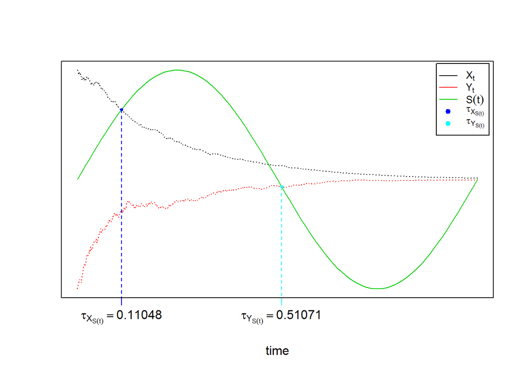

```r
R> plot(ts.union(mod2d$X[,1],mod2d$Y[,1]),col=1:2,lty=3,plot.type="single",type="l",ylab= "",xlab="time",axes=F)
R> curve(sin(2*pi*x),add=TRUE,col=3)
R> points(fpt2d$fpt$x[1],sin(2*pi*fpt2d$fpt$x[1]),pch=19,col=4,cex=0.5)
R> lines(c(fpt2d$fpt$x[1],fpt2d$fpt$x[1]),c(sin(2*pi*fpt2d$fpt$x[1]),-10),lty=2,col=4)
R> axis(1, fpt2d$fpt$x[1], bquote(tau[X[S(t)]]==.(fpt2d$fpt$x[1])),col=4,col.ticks=4)
R> points(fpt2d$fpt$y[1],sin(2*pi*fpt2d$fpt$y[1]),pch=19,col=5,cex=0.5)
R> lines(c(fpt2d$fpt$y[1],fpt2d$fpt$y[1]),c(sin(2*pi*fpt2d$fpt$y[1]),-10),lty=2,col=5)
R> axis(1, fpt2d$fpt$y[1], bquote(tau[Y[S(t)]]==.(fpt2d$fpt$y[1])),col=5,col.ticks=5)
R> legend('topright',col=1:5,lty=c(1,1,1,NA,NA),pch=c(NA,NA,NA,19,19),legend=c(expression(X[t]),expression(Y[t]),expression(S(t)),expression(tau[X[S(t)]]),expression(tau[Y[S(t)]])),cex=0.8,inset = .01)
R> box()
```

The marginal density of $(\tau_{(S(t),X_{t})}$ and $\tau_{(S(t),Y_{t})})$ are reported using `dfptsde2d()` function, see e.g. Figure 6.

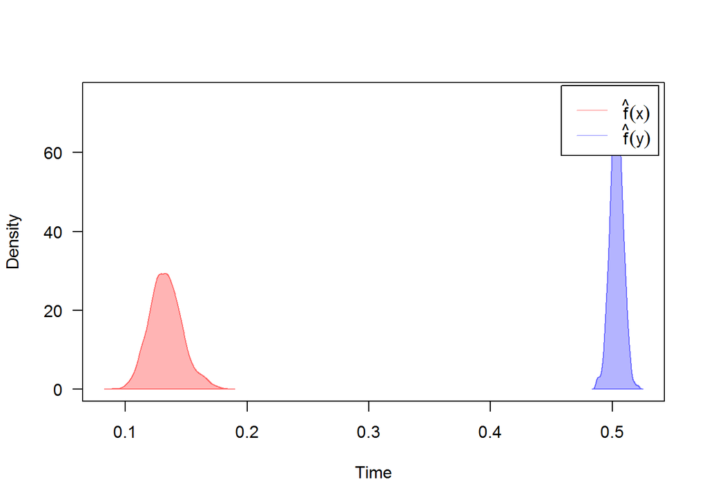

```r
R> denM <- dfptsde2d(fpt2d, pdf = 'M')
R> plot(denM)
```

A `contour` and `image` plot of density obtained from a realization of system $(\tau_{(S(t),X_{t})},\tau_{(S(t),Y_{t})})$.

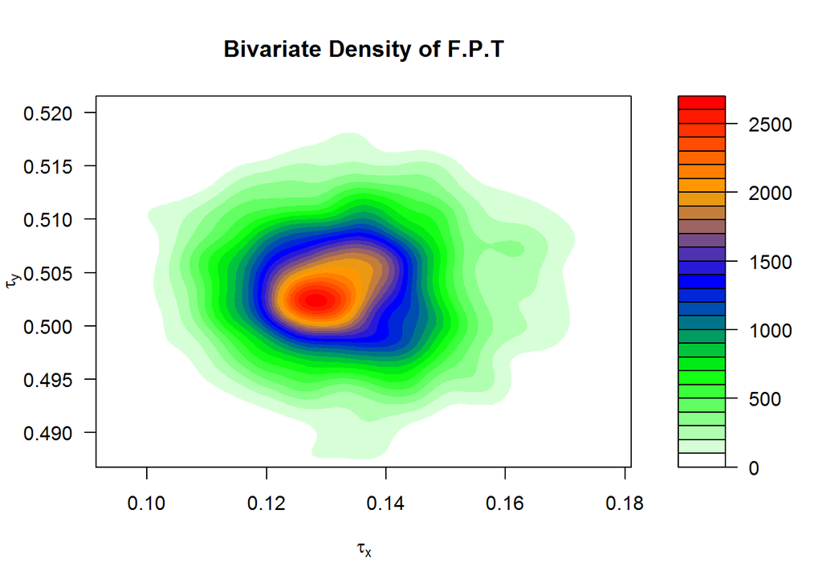

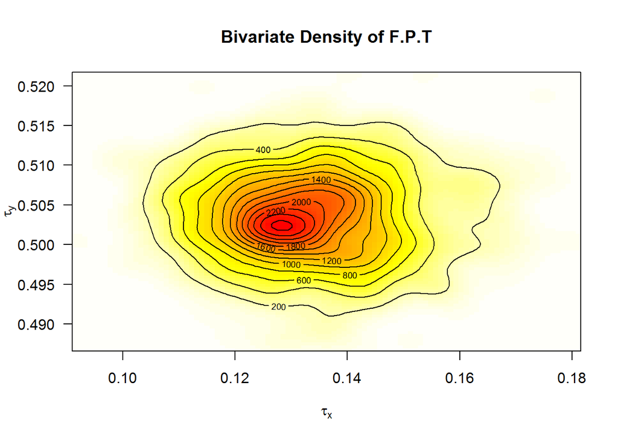

```r
R> denJ <- dfptsde2d(fpt2d, pdf = 'J',n=100)
R> plot(denJ,display="contour",main="Bivariate Density of F.P.T",xlab=expression(tau[x]),ylab=expression(tau[y]))
R> plot(denJ,display="image",main="Bivariate Density of F.P.T",xlab=expression(tau[x]),ylab=expression(tau[y]))
```

A $3$D plot of the Joint density with:

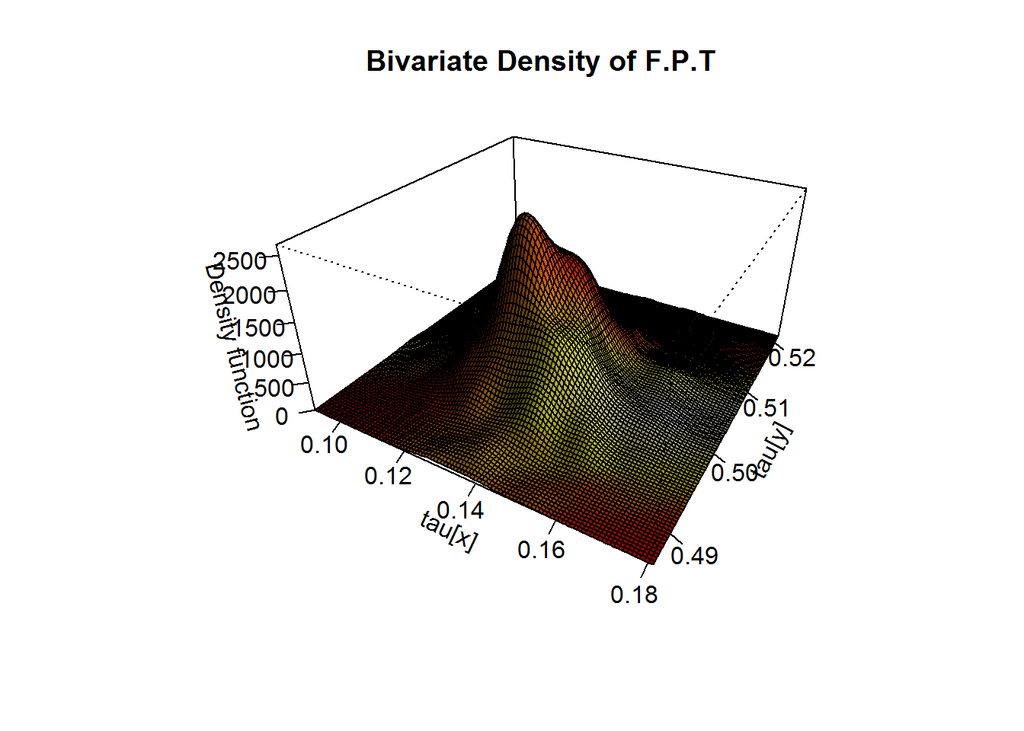

```r
R> plot(denJ,display="persp",main="Bivariate Density of F.P.T",xlab=expression(tau[x]),ylab=expression(tau[y]))
```

Return to fptsde2d()

## FPT for 3-Dim SDE’s

The following $3$-dimensional SDE’s with a vector of drift and a diagonal matrix of diffusion coefficients:

$$\begin{equation}\label{eq17}
\begin{cases}
dX_t = f_{x}(t,X_{t},Y_{t},Z_{t}) dt + g_{x}(t,X_{t},Y_{t},Z_{t}) dW_{1,t}\\
dY_t = f_{y}(t,X_{t},Y_{t},Z_{t}) dt + g_{y}(t,X_{t},Y_{t},Z_{t}) dW_{2,t}\\
dZ_t = f_{z}(t,X_{t},Y_{t},Z_{t}) dt + g_{z}(t,X_{t},Y_{t},Z_{t}) dW_{3,t}
\end{cases}
\end{equation}$$
$W_{1,t}$, $W_{2,t}$ and $W_{3,t}$ is a 3 independent standard Wiener process. First passage time (3D) $(\tau_{(S(t),X_{t})},\tau_{(S(t),Y_{t})},\tau_{(S(t),Z_{t})})$ is defined as:

$$\left\{
\begin{array}{ll}
\tau_{S(t),X_{t}}=\inf \left\{t: X_{t} \geq S(t)|X_{t_{0}}=x_{0} \right\} & \hbox{if} \quad x_{0} \leq S(t_{0}) \\
\tau_{S(t),Y_{t}}=\inf \left\{t: Y_{t} \geq S(t)|Y_{t_{0}}=y_{0} \right\} & \hbox{if} \quad y_{0} \leq S(t_{0}) \\
\tau_{S(t),Z_{t}}=\inf \left\{t: Z_{t} \geq S(t)|Z_{t_{0}}=z_{0} \right\} & \hbox{if} \quad z_{0} \leq S(t_{0})
\end{array}
\right.$$
and
$$\left\{
\begin{array}{ll}
\tau_{S(t),X_{t}}= \inf \left\{t: X_{t} \leq S(t)|X_{t_{0}}=x_{0} \right\} & \hbox{if} \quad x_{0} \geq S(t_{0}) \\
\tau_{S(t),Y_{t}}= \inf \left\{t: Y_{t} \leq S(t)|Y_{t_{0}}=y_{0} \right\} & \hbox{if} \quad y_{0} \geq S(t_{0}) \\
\tau_{S(t),Z_{t}}= \inf \left\{t: Z_{t} \leq S(t)|Z_{t_{0}}=z_{0} \right\} & \hbox{if} \quad z_{0} \geq S(t_{0}) \\
\end{array}
\right.$$

Assume that we want to describe the following SDE’s (3D):
$$\begin{equation}\label{eq0166}
\begin{cases}
dX_t = 4 (-1-X_{t}) Y_{t} dt + 0.2 dW_{1,t}\\
dY_t = 4 (1-Y_{t}) X_{t} dt + 0.2 dW_{2,t}\\
dZ_t = 4 (1-Z_{t}) Y_{t} dt + 0.2 dW_{3,t}
\end{cases}
\end{equation}$$
and
$$S(t)=-1.5+3t$$

Set the system $(X_t , Y_t , Z_t)$:

```r
R> fx <- expression(4*(-1-x)*y , 4*(1-y)*x , 4*(1-z)*y)
R> gx <- rep(expression(0.2),3)
R> mod3d <- snssde3d(drift=fx,diffusion=gx,x0=c(x=2,y=-2,z=0),M=1000)
```

Generate the triplet $(\tau_{(S(t),X_{t})},\tau_{(S(t),Y_{t})},\tau_{(S(t),Z_{t})})$, with `fptsde3d()` function::

```r
R> St <- expression(-1.5+3*t)
R> fpt3d <- fptsde3d(mod3d, boundary = St)
R> fpt3d
```

```
Itô Sde 3D:
    | dX(t) = 4 * (-1 - X(t)) * Y(t) * dt + 0.2 * dW1(t)
    | dY(t) = 4 * (1 - Y(t)) * X(t) * dt + 0.2 * dW2(t)
    | dZ(t) = 4 * (1 - Z(t)) * Y(t) * dt + 0.2 * dW3(t)
    | t in [0,1].
Boundary:
    | S(t) = -1.5 + 3 * t
F.P.T:
    | T(S(t),X(t)) = inf{t >=  0 : X(t) <=  -1.5 + 3 * t }
    |   And
    | T(S(t),Y(t)) = inf{t >=  0 : Y(t) >=  -1.5 + 3 * t }
    |   And
    | T(S(t),Z(t)) = inf{t >=  0 : Z(t) <=  -1.5 + 3 * t }
    | Crossing realized 1000 among 1000.
```

```r
R> head(fpt3d$fpt, n = 10)
```

```
         x        y       z
1  0.52670 0.024297 0.78568
2  0.50634 0.023111 0.80254
3  0.54032 0.023006 0.78718
4  0.52996 0.024950 0.76237
5  0.52370 0.023213 0.80861
6  0.55294 0.023462 0.80313
7  0.54789 0.023400 0.75685
8  0.53502 0.024272 0.80064
9  0.54227 0.023340 0.75972
10 0.52042 0.026061 0.74419
```

The following statistical measures (`S3 method`) for class `fptsde3d()` can be approximated for the triplet $(\tau_{(S(t),X_{t})},\tau_{(S(t),Y_{t})},\tau_{(S(t),Z_{t})})$:

```r
R> mean(fpt3d)
```

```
[1] 0.53251 0.02320 0.78277
```

```r
R> moment(fpt3d , center = TRUE , order = 2) ## variance
```

```
[1] 0.0001832797 0.0000016427 0.0008785594
```

```r
R> Median(fpt3d)
```

```
[1] 0.53202 0.02316 0.78254
```

```r
R> Mode(fpt3d)
```

```
[1] 0.529438 0.023076 0.781245
```

```r
R> quantile(fpt3d)
```

```
$x
     0%     25%     50%     75%    100%
0.49597 0.52343 0.53202 0.54113 0.57705

$y
      0%      25%      50%      75%     100%
0.019666 0.022292 0.023160 0.024105 0.027957

$z
     0%     25%     50%     75%    100%
0.68368 0.76365 0.78254 0.80254 0.87476
```

```r
R> kurtosis(fpt3d)
```

```
[1] 2.9722 2.9424 3.2112
```

```r
R> skewness(fpt3d)
```

```
[1]  0.186492  0.096446 -0.191374
```

```r
R> cv(fpt3d)
```

```
[1] 0.025436 0.055273 0.037885
```

```r
R> min(fpt3d)
```

```
[1] 0.495971 0.019666 0.683675
```

```r
R> max(fpt3d)
```

```
[1] 0.577047 0.027957 0.874757
```

```r
R> moment(fpt3d , center= TRUE , order = 4)
```

```
[1] 0.0000001000405227 0.0000000000079564 0.0000024836149789
```

```r
R> moment(fpt3d , center= FALSE , order = 4)
```

```
[1] 0.08072072765 0.00000029503 0.37865036624
```

The result summaries of the triplet $(\tau_{(S(t),X_{t})},\tau_{(S(t),Y_{t})},\tau_{(S(t),Z_{t})})$:

```r
R> summary(fpt3d)
```

```
Monte-Carlo Statistics for the F.P.T of (X(t),Y(t),Z(t))
    | T(S(t),X(t)) = inf{t >=  0 : X(t) <=  -1.5 + 3 * t }
    |    And
    | T(S(t),Y(t)) = inf{t >=  0 : Y(t) >=  -1.5 + 3 * t }
    |    And
    | T(S(t),Z(t)) = inf{t >=  0 : Z(t) <=  -1.5 + 3 * t }
                  T(S,X)  T(S,Y)   T(S,Z)
Mean             0.53251 0.02320  0.78277
Variance         0.00018 0.00000  0.00088
Median           0.53202 0.02316  0.78254
Mode             0.52944 0.02308  0.78125
First quartile   0.52343 0.02229  0.76365
Third quartile   0.54113 0.02410  0.80254
Minimum          0.49597 0.01967  0.68368
Maximum          0.57705 0.02796  0.87476
Skewness         0.18649 0.09645 -0.19137
Kurtosis         2.97220 2.94245  3.21124
Coef-variation   0.02544 0.05527  0.03789
3th-order moment 0.00000 0.00000  0.00000
4th-order moment 0.00000 0.00000  0.00000
5th-order moment 0.00000 0.00000  0.00000
6th-order moment 0.00000 0.00000  0.00000
```

Display the exact first-passage-time $\tau_{S(t)}$, see Figure 9:

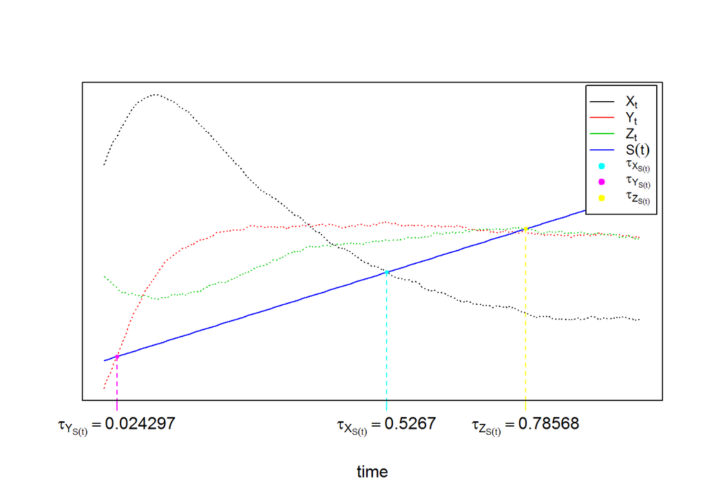

```r
R> plot(ts.union(mod3d$X[,1],mod3d$Y[,1],mod3d$Z[,1]),col=1:3,lty=3,plot.type="single",type="l",ylab="",xlab="time",axes=F)
R> curve(-1.5+3*x,add=TRUE,col=4)
R> points(fpt3d$fpt$x[1],-1.5+3*fpt3d$fpt$x[1],pch=19,col=5,cex=0.5)
R> lines(c(fpt3d$fpt$x[1],fpt3d$fpt$x[1]),c(-1.5+3*fpt3d$fpt$x[1],-10),lty=2,col=5)
R> axis(1, fpt3d$fpt$x[1], bquote(tau[X[S(t)]]==.(fpt3d$fpt$x[1])),col=5,col.ticks=5)
R> points(fpt3d$fpt$y[1],-1.5+3*fpt3d$fpt$y[1],pch=19,col=6,cex=0.5)
R> lines(c(fpt3d$fpt$y[1],fpt3d$fpt$y[1]),c(-1.5+3*fpt3d$fpt$y[1],-10),lty=2,col=6)
R> axis(1, fpt3d$fpt$y[1], bquote(tau[Y[S(t)]]==.(fpt3d$fpt$y[1])),col=6,col.ticks=6)
R> points(fpt3d$fpt$z[1],-1.5+3*fpt3d$fpt$z[1],pch=19,col=7,cex=0.5)
R> lines(c(fpt3d$fpt$z[1],fpt3d$fpt$z[1]),c(-1.5+3*fpt3d$fpt$z[1],-10),lty=2,col=7)
R> axis(1, fpt3d$fpt$z[1], bquote(tau[Z[S(t)]]==.(fpt3d$fpt$z[1])),col=7,col.ticks=7)
R> legend('topright',col=1:7,lty=c(1,1,1,1,NA,NA,NA),pch=c(NA,NA,NA,NA,19,19,19),legend=c(expression(X[t]),expression(Y[t]),expression(Z[t]),expression(S(t)),expression(tau[X[S(t)]]),expression(tau[Y[S(t)]]),expression(tau[Z[S(t)]])),cex=0.8,inset = .01)
R> box()
```

The marginal density of $\tau_{(S(t),X_{t})}$ ,$\tau_{(S(t),Y_{t})}$ and $\tau_{(S(t),Z_{t})})$ are reported using `dfptsde3d()` function, see e.g. Figure 10.

```r
R> denM <- dfptsde3d(fpt3d, pdf = "M")
R> denM
```

[output not shown]

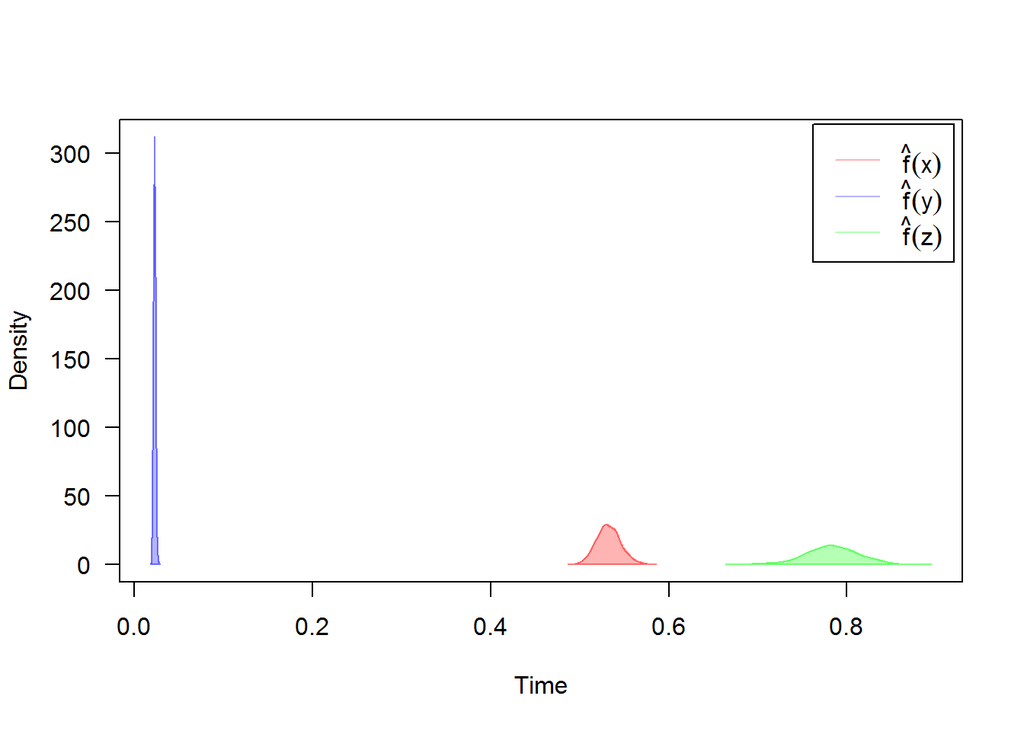

```r
R> plot(denM)
```

For an approximate joint density for $(\tau_{(S(t),X_{t})},\tau_{(S(t),Y_{t})},\tau_{(S(t),Z_{t})})$ (for more details, see package sm or ks.)

```r
R> denJ <- dfptsde3d(fpt3d,pdf="J")
R> plot(denJ,display="rgl")
```

Return to fptsde3d()

# Further reading

1. `snssdekd()` & `dsdekd()` & `rsdekd()`- Monte-Carlo Simulation and Analysis of Stochastic Differential Equations.
2. `bridgesdekd()` & `dsdekd()` & `rsdekd()` - Constructs and Analysis of Bridges Stochastic Differential Equations.
3. `fptsdekd()` & `dfptsdekd()` - Monte-Carlo Simulation and Kernel Density Estimation of First passage time.
4. `MCM.sde()` & `MEM.sde()` - Parallel Monte-Carlo and Moment Equations for SDEs.
5. `TEX.sde()` - Converting Sim.DiffProc Objects to LaTeX.
6. `fitsde()` - Parametric Estimation of 1-D Stochastic Differential Equation.

# References

1. Boukhetala K (1996). Modelling and Simulation of a Dispersion Pollutant with Attractive Centre, volume 3, pp. 245-252. Computer Methods and Water Resources, Computational Mechanics Publications, Boston, USA.
2. Boukhetala K (1998). Estimation of the first passage time distribution for a simulated diffusion process. Maghreb Mathematical Review, 7, pp. 1-25.
3. Boukhetala K (1998). Kernel density of the exit time in a simulated diffusion. The Annals of The Engineer Maghrebian, 12, pp. 587-589.
4. Guidoum AC, Boukhetala K (2020). Sim.DiffProc: Simulation of Diffusion Processes. R package version 4.5, URL https://cran.r-project.org/package=Sim.DiffProc.
5. Pienaar EAD, Varughese MM (2016). DiffusionRgqd: An R Package for Performing Inference and Analysis on Time-Inhomogeneous Quadratic Diffusion Processes. R package version 0.1.3, URL https://CRAN.R-project.org/package=DiffusionRgqd.
6. Roman, R.P., Serrano, J. J., Torres, F. (2008). First-passage-time location function: Application to determine first-passage-time densities in diffusion processes. Computational Statistics and Data Analysis. 52, 4132-4146.
7. Roman, R.P., Serrano, J. J., Torres, F. (2012). An R package for an efficient approximation of first-passage-time densities for diffusion processes based on the FPTL function. Applied Mathematics and Computation, 218, 8408-8428.
[^1]: Department of Probabilities & Statistics, Faculty of Mathematics, University of Science and Technology Houari Boumediene, BP 32 El-Alia, U.S.T.H.B, Algeria, E-mail (acguidoum@usthb.dz)
[^2]: Faculty of Mathematics, University of Science and Technology Houari Boumediene, BP 32 El-Alia, U.S.T.H.B, Algeria, E-mail (kboukhetala@usthb.dz)